Kompetensförsörjning  
i Dalarna

# Kompetensförsörjning i Dalarna

Rapporten är skapad av Samhällsanalys, Region Dalarna  
Senast uppdaterad: 2026-10-30

# Sammanfattning

Dalarna står inför en tydlig kompetensförsörjningsutmaning: befolkningen åldras snabbare än i riket, den arbetsföra befolkningen krymper, och samtidigt ökar efterfrågan på arbetskraft. Resultatet är en arbetsmarknad där allt fler arbetsgivare, särskilt små och medelstora företag, har svårt att hitta rätt kompetens.

- **Efterfrågan ökar.** Antalet lediga jobb i Dalarna har ökat påtagligt de senaste decennierna, framför allt inom privat sektor.
- **Utbudet minskar.** Den inrikes födda befolkningen i arbetsför ålder blir färre. Att fler utrikes födda bor i länet dämpar minskningen, men kompenserar inte fullt ut.
- **Utbildningsnivån är låg.** Dalarna har en av landets lägsta andelar eftergymnasialt utbildade, vilket gör det svårare att möta arbetsgivarnas kompetenskrav inom flera växande yrkesområden.
- **Åldersstrukturen förstärker problemet.** Stora delar av arbetskraften inom bland annat vård och omsorg samt tillverkning går i pension inom 15-20 år.
- **Konsekvensen syns redan idag:** knappt fyra av tio mindre företag i Dalarna uppger att de har svårt att hitta rätt kompetens för att utveckla verksamheten.

**Mer om rapporten och statistiken**

Webbrapportformatet ger möjligheter att enkelt automatisera uppdateringar när ny statistik finns tillgänglig. Publiceringsdatum visas längst upp på sidan.

Vill du utforska statistiken närmare - jämföra kommuner, län eller titta på fler år - hittar du det i våra Shiny-rapporter om kompetensförsörjning med fokus på [utbildning](https://shiny.regiondalarna.se/utbildning/) respektive [branscher](https://shiny.regiondalarna.se/branscher/).

För att förstora diagrammen i rapporten, högerklicka på ett diagram och välj alternativet “Öppna bild i ny flik”.

I rapporten används både sysselsättningsgrad och arbetslöshet som begrepp. Sysselsättningsgraden mäter andelen sysselsatta i förhållande till hela befolkningen i en viss åldersgrupp (här 20–64 år). Arbetslösheten mäts som andelen arbetslösa i förhållande till den totala arbetskraften. För att räknas som arbetslös behöver en individ arbetskraften. De som står utanför arbetskraften, t ex studerande, räknas m a o inte som arbetslösa.

Från och med referensåret 2025 och framåt har SCB infört en liten kontrollerad slumpmässig osäkerhet (CKM) i befolkningsstatistiken. Osäkerheten har tillförts för att skydda enskilda personer så att ingen riskerar att röjas i statistiken. Till följd av detta så är inte alltid de redovisade totalerna lika med summan av deras redovisade delar. Läs mer om det på [SCB:s hemsida](https://www.scb.se/nyhet/ny-metod-for-integritetsskydd-i-befolkningsstatistiken/).

# Inledning

Sverige och Dalarna har en åldrande befolkning. Aktuella prognoser från SCB (SCB, 2026) pekar på en utveckling där allt färre i arbetsför ålder ska försörja i synnerhet allt fler gamla. Mellan 2006 och 2025 har den demografiska försörjningskvoten i Dalarna ökat från ungefär 76 till ungefär 92, en av de högsta i landet, och den väntas fortsätta öka. Det förstärker den brist på arbetskraft som redan finns.

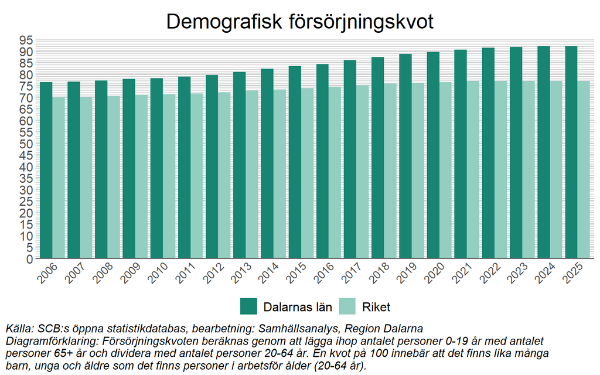

Figur 1.

Att hitta lösningar på kompetensförsörjningsutmaningen är avgörande för en hållbar regional utveckling. Den regionala utvecklingsstrategin, [Dalastrategin 2030](https://www.regiondalarna.se/contentassets/0e5aa308f6be448a85e9818fbeb0a919/dalastrategin_uppl2026.pdf), pekar ut en väl fungerande kompetensförsörjning som ett område där nya lösningar måste hittas.

Rapporten är strukturerad kring hur kompetensförsörjningssystemet hänger ihop: efterfrågan på arbetskraft möter ett utbud som formas av demografi, utbildningsnivå och pendling. Utbildningssystemet ska i sin tur förse arbetsmarknaden med rätt kompetens över tid. När delarna inte möts uppstår en brist som många arbetsgivare i Dalarna redan upplever idag.

# 1 Efterfrågan på arbetskraft

[Reglab (2014)](https://tillvaxtverket.se/download/18.27a54dd21870d50fcb36cd6/1679644966939/Regionala-Matchningsindikatorer-%E2%88%92-dec-2014.pdf) definierar arbetskraftsefterfrågan som *“mängden arbetskraft och dess egenskaper - kompetens, kunskaper, utbildning, yrkeserfarenheter - som arbetsgivare efterfrågar och/eller behöver, i nuläget eller längre fram”*. Den här rapporten mäter efterfrågan i första hand genom lediga jobb och inflödet av jobb, i linje med Reglabs regionala matchningsindikatorer.

## 1.1 Lediga jobb och jobbinflöde

Under andra kvartalet 2026 fanns det cirka 3 600 lediga jobb i Dalarna, varav ungefär 86 procent inom privat sektor. Efterfrågan inom offentlig sektor har minskat på senare år, sannolikt kopplat till en försämrad ekonomi och anställningsstopp hos flera offentliga aktörer. Över tid har antalet lediga jobb ökat successivt sedan bottennoteringen efter finanskrisen 2008.

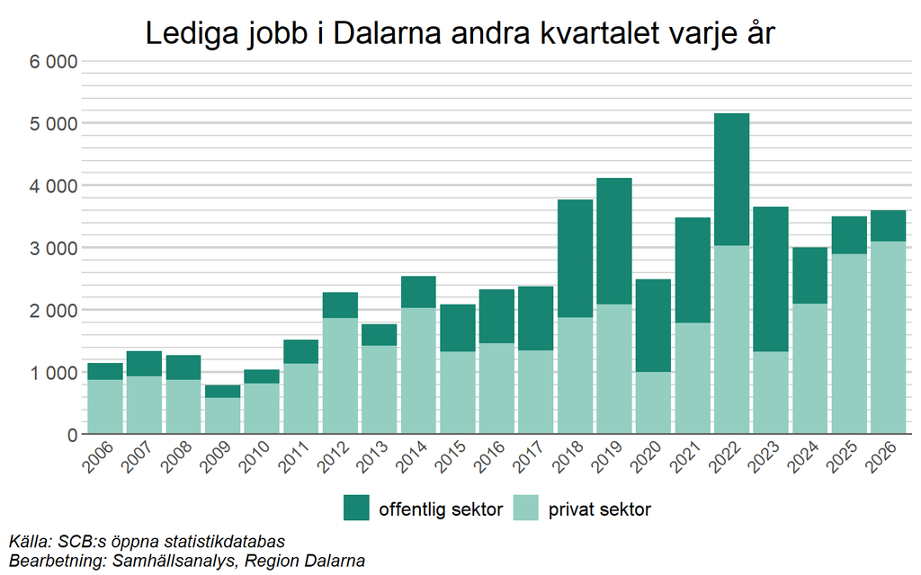

Figur 2.

Majoriteten av lediga tjänster tillsätts av personer som redan är aktiva i yrkeslivet (“jobbytare”), inte av nyinträdda på arbetsmarknaden. De nyinträdda står bara för 5-6 procent av tillsättningarna. Det förhållandet har varit stabilt över tid.

## 1.2 Kompetenskrav

**Mer information om statistiken**

För att beskriva kompetens- och kvalifikationskrav har denna rapport utgått ifrån yrkesregistret i SCB:s öppna statistikdatabas, som delar in yrken i nio grupper. Läs mer på [SCB:s hemsida](https://www.scb.se/dokumentation/klassifikationer-och-standarder/standard-for-svensk-yrkesklassificering-ssyk/).

Vilken typ av kompetens arbetsgivare efterfrågar varierar stort mellan branscher. I Dalarna finns den enklaste typen av yrken framför allt inom hotell och restaurang. Här finns också finns även flest utrikes födda anställda. Motsatsen gäller inom utbildning, offentlig förvaltning samt IT och kommunikation, där omkring hälften av de anställda arbetar inom yrken som kräver motsvarande fördjupad högskolekompetens.

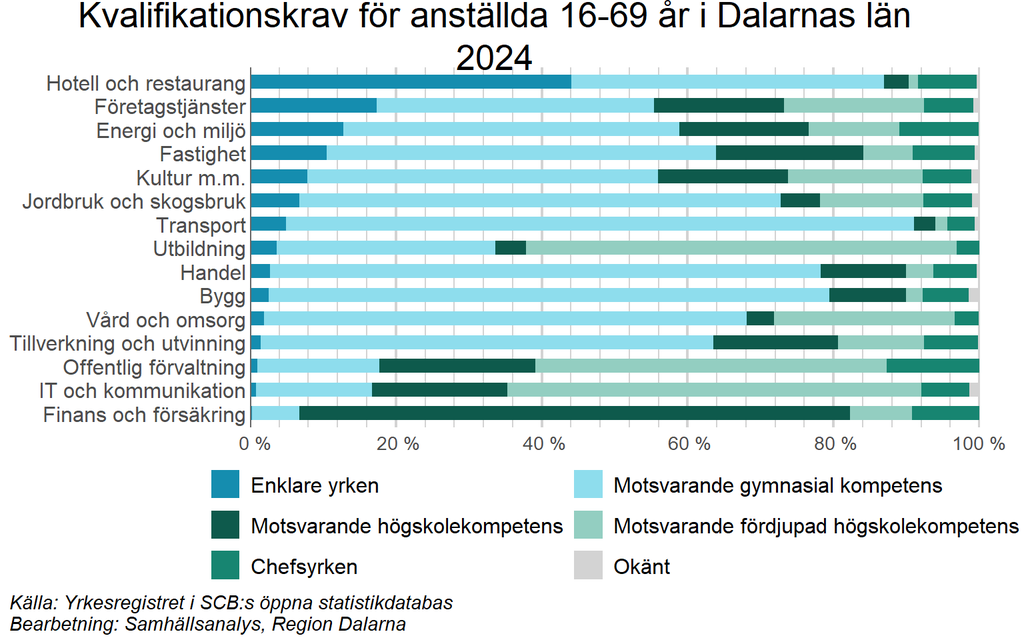

Figur 3.

## 1.3 Demografisk struktur per bransch

Det finns ett omfattande material att utforska när det gäller ålder, kön och bakgrund ur ett branschperspektiv. Den som är intresserad av att fördjupa sig inom en viss bransch eller ett visst perspektiv, t ex förväntade pensionsavgångar i närtid utifrån nuvarande ålderssammansättning, hänvisas till fliken Demografi i [Shiny-rapporten](https://shiny.regiondalarna.se/branscher/).

# 2 Utbud av arbetskraft

Utbudet av arbetskraft i Dalarna formas på kort sikt av vilka som redan bor, kan pendla till eller kan distansarbeta i länet. På längre sikt avgörs det av befolkningsutveckling, utbildningsnivå och in- och utflyttning.

## 2.1 En förändrad demografisk struktur

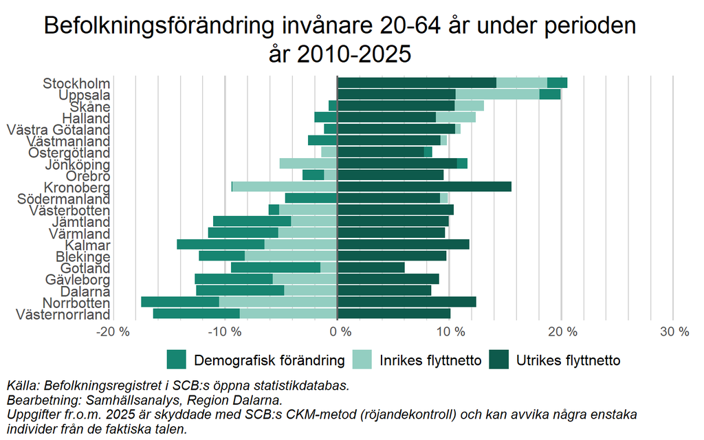

Figur 4.

Delar man upp den arbetsföra befolkningen i inrikes och utrikes födda blir bilden tydligare att det är den inrikes födda delen som minskar, medan invandring gjort att antalet utrikes födda i arbetsför ålder ökat, dock inte tillräckligt för att kompensera fullt ut. I Dalarna har antalet inrikes födda invånare i arbetsför ålder minskat från ungefär 145 000 personer år 2000 till knappt 123 000 år 2025.

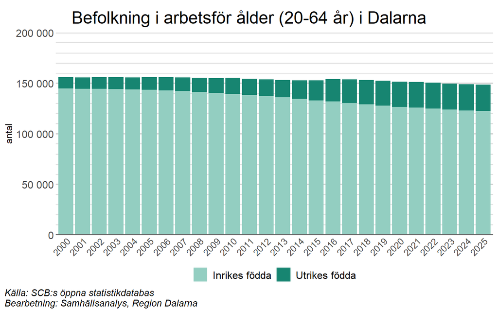

Figur 5.

Samma mönster syns när befolkningen delas upp i åldersgrupper. De unga (0-19 år) och de i arbetsför ålder (20-64 år) har minskat sedan slutet på 1960-talet, medan de äldre, särskilt 80+ år, har ökat kraftigt. Det är en utveckling som förväntas fortsätta kommande år.

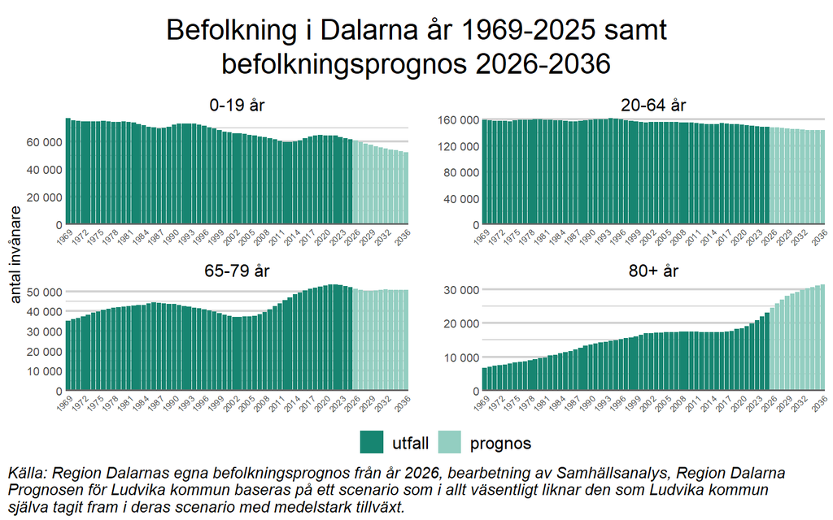

Figur 6.

## 2.2 Arbetskraftsdeltagande

Sedan 2006 har arbetskraftsdeltagandet ökat för både kvinnor och män i arbetsför ålder, och skillnaden mellan könen har minskat över tid. Under 2024 var andelen ungefär 88 procent för män och 86 procent för kvinnor, båda högre än riksgenomsnittet.

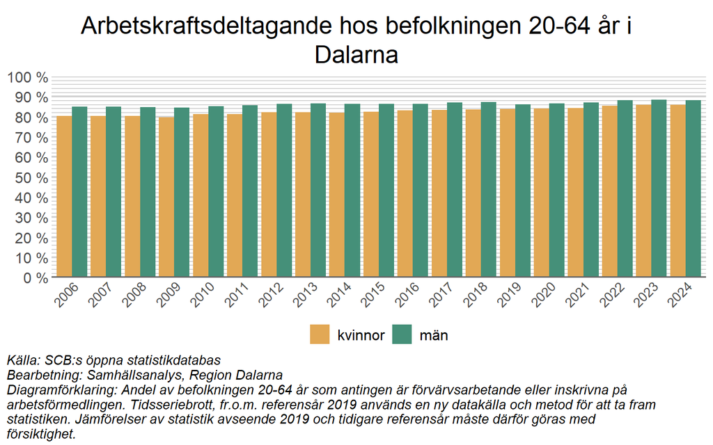

Figur 7.

## 2.3 Förvärvsarbetande

Vård och omsorg är idag Dalarnas klart största bransch räknat i antal anställda, en följd av en relativt hög medelålder i länet. SCB bedömer att behovet av arbetskraft inom vård och omsorg kommer att fortsätta öka i takt med den åldrande befolkningen ([SCB, 2025](https://www.scb.se/contentassets/04cf1ee0f04b4c06a6e62d22d78e8d4c/dalarnas-lan-20251215.pdf)).

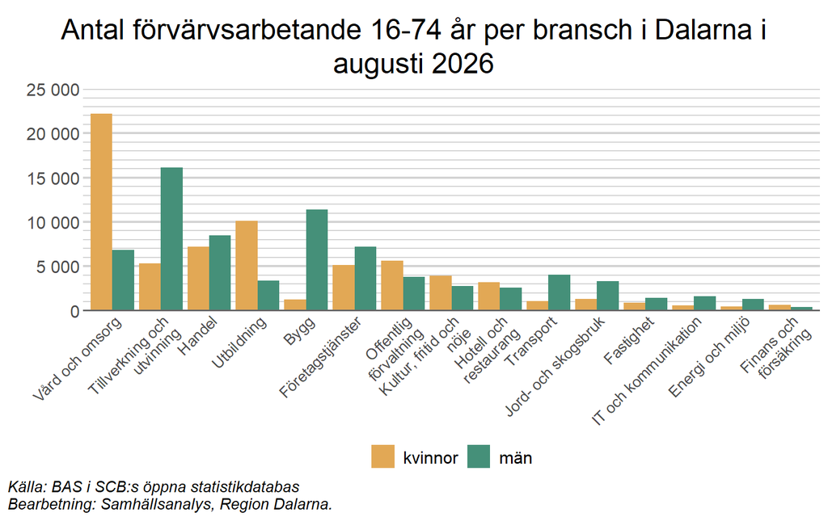

Figur 8.

Historiskt var tillverkning och utvinning Dalarnas största bransch, men den har minskat sedan 1990 i takt med en mer automatiserad produktion och en generell förskjutning mot tjänstesektorn. Företagstjänster och finans har istället vuxit kraftigt, delvis för att verksamhet som tidigare skedde i egen regi (till exempel lokalvård) numera ofta upphandlas och därmed räknas till en annan bransch. Noterbart är att branschen tillverkning och utvinning under senare år återigen ökar i antalet förvärvsarbetande i takt med Hitachi Energys expansion i Ludvika. Effekten på lång sikt är trots det en minskning med drygt 12 000 förvärvsarbetande sedan 1990.

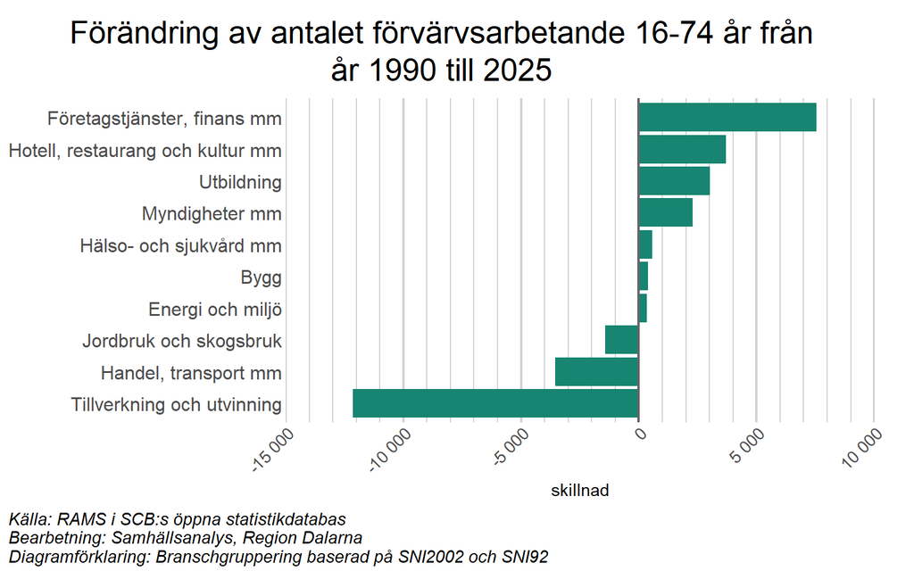

Figur 9.

Näringslivets sammansättning skiljer sig tydligt åt mellan Dalarnas kommuner. Tillverkningsindustrin dominerar fortfarande i söder (Avesta, Ludvika), vård och omsorg är viktigast där det finns akutsjukhus (Falun, Mora) samt i Säter och Rättvik, handel är stort i Leksand, och byggindustrin är en av de största branscherna i fjällkommunerna i norr.

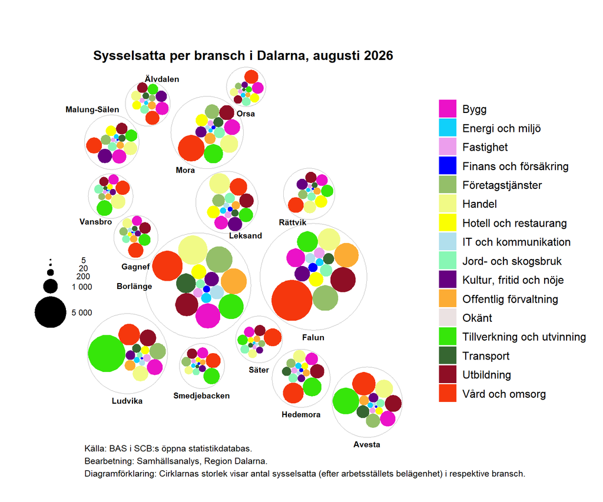

Figur 10.

## 2.4 Pendling

Pendling kan stärka en svag lokal arbetsmarknad genom att öppna upp fler möjligheter till jobb. I Dalarna är andelen som pendlar över länsgräns relativt liten, men flera kommuner tillhör större lokala arbetsmarknadsregioner. Till exempel pendlar många från Gagnef till Borlänge, från Smedjebacken till Ludvika och från Orsa till Mora. I de till ytan stora kommunerna i norra Dalarna (Malung-Sälen, Älvdalen) bor och arbetar däremot de allra flesta i samma kommun.

Skillnaderna mellan Dalarnas kommuner, och mellan Dalarna och andra län kommer att kunna utforskas i [Shiny-rapporten](https://shiny.regiondalarna.se/branscher/), fliken Rörlighet och hälsa (under arbete).

## 2.5 Utbildningsnivå

Utbildningsnivån i Dalarna har ökat påtagligt över tid. Andelen kvinnor med minst tre års eftergymnasial utbildning har gått från ungefär 7 till 32 procent mellan 1985 och 2025, och andelen män från 7 till 17 procent. Trots ökningen har Dalarna en av landets lägsta andelar högutbildade. År 2025 var andelen tredje lägst av alla län i Sverige.

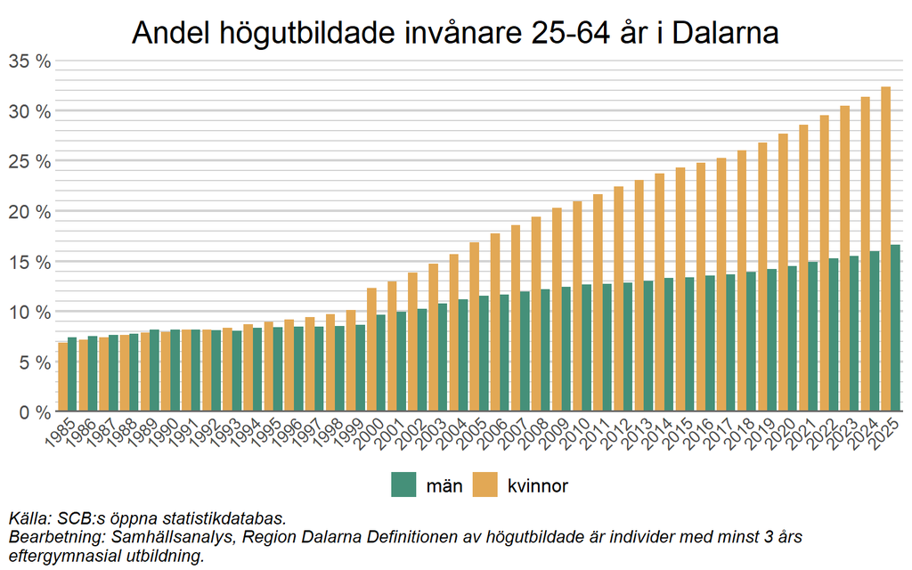

Figur 11.

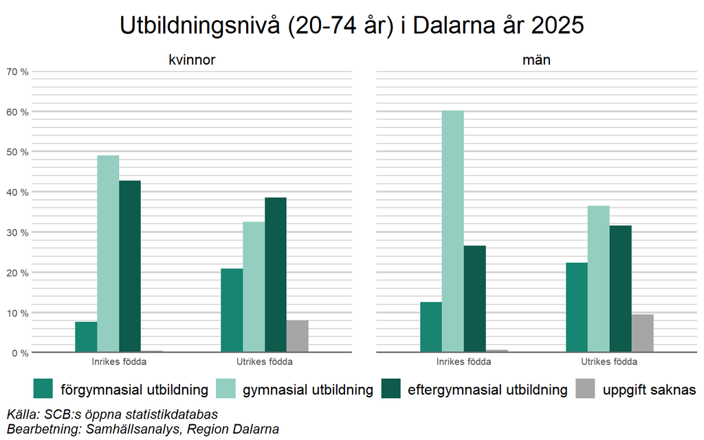

Figur 12.

# 3 Utbildningssystemets roll

En väl fungerande kompetensförsörjning kräver att utbildningssystemet är anpassat till arbetsmarknadens behov, från gymnasiet, via vuxenutbildning och yrkeshögskola, till högskola och universitet.

Efter grundskolan kan eleverna fortsätta till **gymnasieskolan**, som är tre år och förbereder för högre utbildning eller för arbetsmarknaden, via högskoleförberedande eller yrkesinriktade program. Några mindre kommuner i Dalarna saknar egen gymnasieutbildning och samverkar i stället med andra kommuner.

För vuxna finns flera vägar att utbilda sig. **Komvux/DalaWux** är kommunal vuxenutbildning där man kan komplettera grundskole- eller gymnasieutbildning, och även läsa vissa yrkesutbildningar. **Yrkeshögskolan (YH)** bedrivs i samarbete med näringslivet och syftar till jobb direkt efter examen. Ungefär en tredjedel av utbildningen sker som praktik (LIA), och de flesta utbildningarna är 1–2 år långa. **Folkhögskolorna** erbjuder utbildning på informell nivå, öppen för alla oavsett tidigare utbildning, med fokus på personlig utveckling snarare än formella examina. **Arbetsmarknadsutbildning** är slutligen kortare, yrkesinriktad utbildning i Arbetsförmedlingens regi, riktad mot bristyrken och mot personer som har svårt att hitta jobb.

De tydligaste könsskillnaderna i utbildningsval syns redan vid gymnasievalet, och de återspeglas senare i arbetslivet där kvinnor är överrepresenterade inom vård, omsorg och utbildning, medan män dominerar byggsektorn. Ska fördelningen mellan branscher bli mer jämställd på sikt behöver arbetet börja redan i skolan.

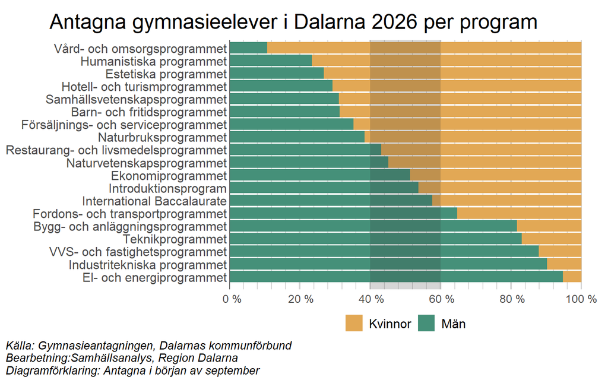

Figur 13.

Statistik om antagning per gymnasieprogram, examina från Högskolan Dalarna och yrkeshögskolan går att följa i detalj i [Shiny-rapporten](https://shiny.regiondalarna.se/utbildning/), inklusive utveckling år för år och per inriktning.

# 4 Arbetsmarknaden i Dalarna

En väl fungerande arbetsmarknad kännetecknas av att många arbetar, att de arbetar med det de är utbildade till, och att kompetensbristen är liten. Det här avsnittet sammanfattar hur väl det stämmer för Dalarna idag.

## 4.1 Sysselsättningsgrad

Sysselsättningsgraden har ökat över tid för både kvinnor och män i Dalarna, från omkring 70 procent för båda könen 1993, till 82 respektive 84 procent 2024.

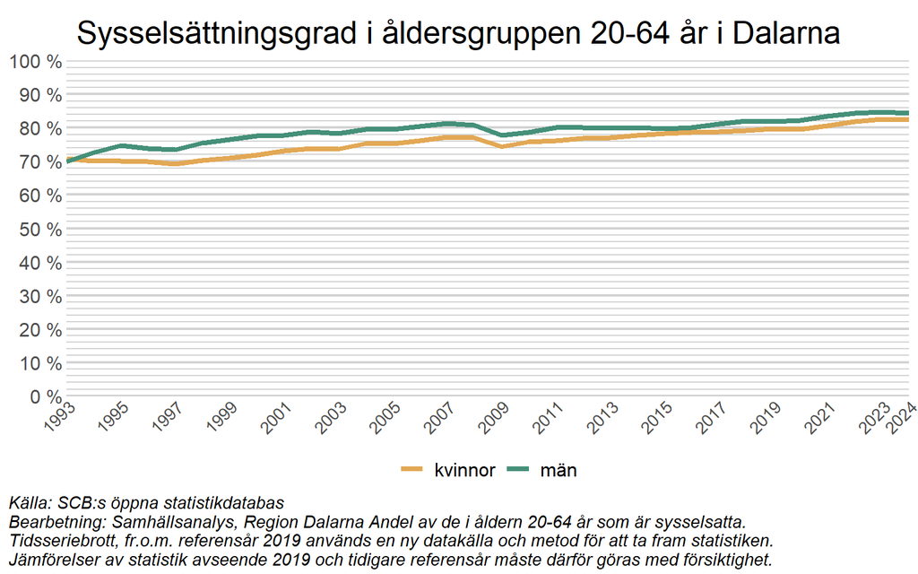

Figur 14.

Den stora skillnaden i sysselsättningsgrad finns inte mellan kvinnor och män, utan mellan inrikes och utrikes födda. Det är ett mönster som gäller i hela landet, och som till stor del hänger ihop med den lägre utbildningsnivån bland utrikes födda som beskrevs tidigare i rapporten. Skillnaden mellan Dalarnas kommuner ur ett utbildningsperspektiv går att utforska i [Shiny-rapporten](https://shiny.regiondalarna.se/branscher/) under fliken Utbildning & yrken.

## 4.2 Arbetslöshet

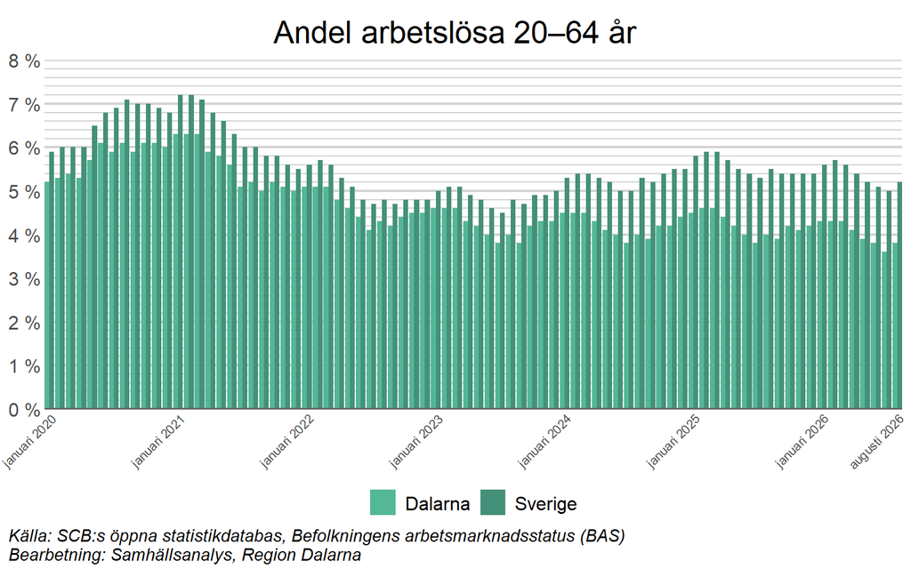

Figur 15.

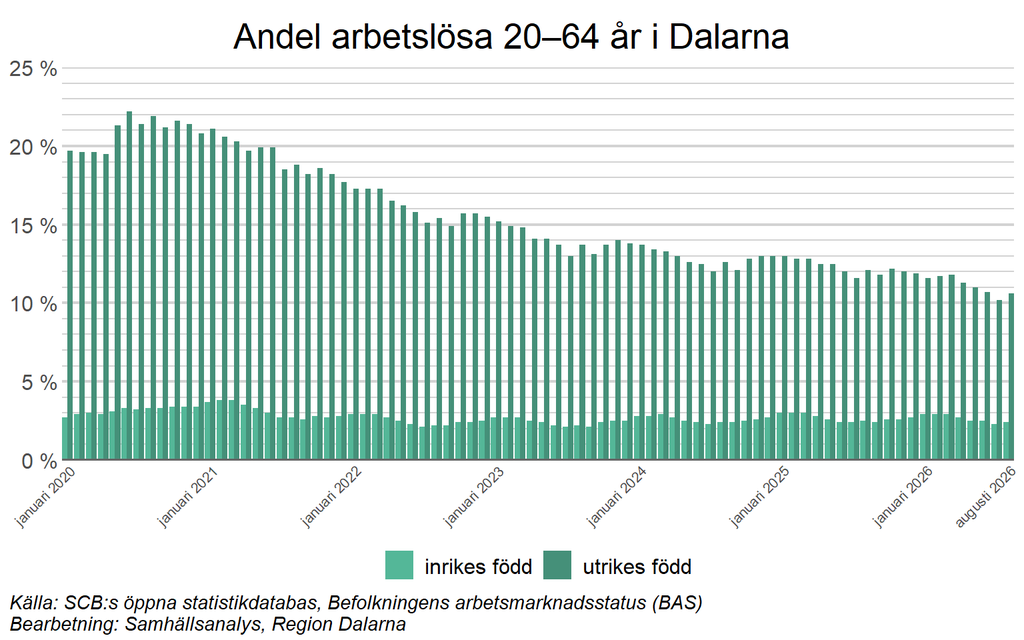

Figur 16.

## 4.3 Matchning på arbetsmarknaden

Matchning mäter i hur stor utsträckning människor arbetar med det de är utbildade till. Generellt har specialiserade eftergymnasiala utbildningar (till exempel läkare och psykologer) hög matchning, medan gymnasieutbildningar och vissa eftergymnasiala inriktningar (till exempel humaniora och konst) har lägre.

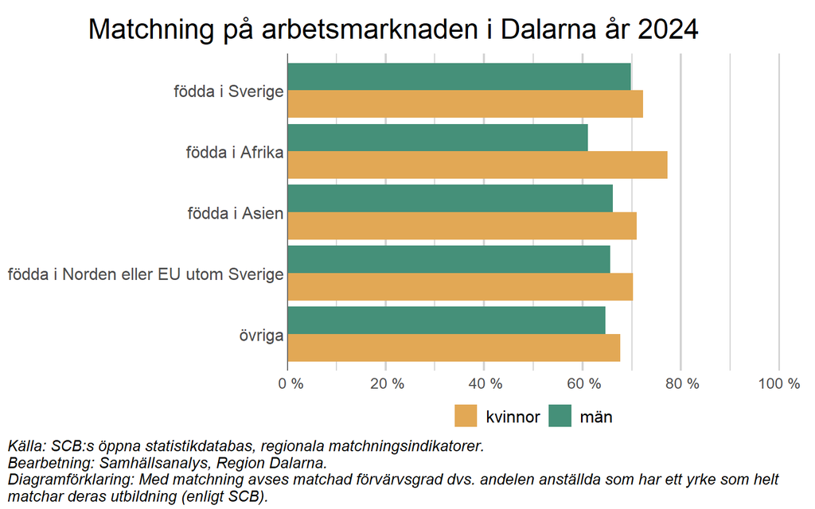

Figur 17.

Matchningsgraden varierar även tydligt beroende exempelvis vilket yrke man har, se fliken matchning i [Shiny-rapporten](https://shiny.regiondalarna.se/branscher/).

## 4.4 Brist på arbetskraft och kompetens

Tillväxtverket undersöker företagens villkor och verklighet vart tredje år och den senaste undersökningen visar att den den upplevda bristen på arbetskraft varierar en hel del bland Sveriges län ([Tillväxtverket, 2026](https://tillvaxtverket.se/tillvaxtverket/publikationer/publikationer2026/foretagensvillkorochverklighet2026.12421.html)).

I Dalarna upplever ungefär 40 procent av små och medelstora företag att de har svårt att hitta rätt kompetens - en ökning med 12 procentenheter sedan 2020, och relativt lika utfallet vid undersökningen 2023.

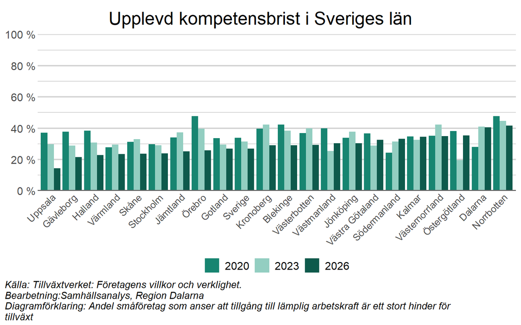

Figur 18.

Det är svårt att skilja brist på arbetskraft från brist på kompetens. En krympande arbetsför befolkning ger en generell brist på arbetskraft, men förstärker sannolikt även kompetensbristen eftersom arbetskraftsreserven minskar. Arbetsgivare tvingas anställa personer som står längre från kompetenskraven, vilket ökar behovet av vidareutbildning efter anställning. För ett djupare resonemang, se [Tillväxtanalys, 2024](https://www.tillvaxtanalys.se/publikationer/rapport/rapportserien/arbetskraftsochkompetensbrist.126683.html).

# 5 Sammanfattande diskussion

Kompetensförsörjningen i Dalarna handlar i grunden om att ekvationen mellan efterfrågan och utbud på arbetskraft blir allt svårare att få ihop. Efterfrågan på arbetskraft fortsätter att öka, driven framför allt av privat sektor och av en åldrande befolkning som kräver mer vård och omsorg. Samtidigt krymper utbudet när den inrikes födda befolkningen i arbetsför ålder minskar. Även om utrikes födda delvis kompenserar för det, räcker det inte fullt ut.

Två strukturella svagheter förstärker obalansen. Dels har Dalarna en relativt låg utbildningsnivå jämfört med andra län, vilket gör det svårare att möta de kompetenskrav som växer inom flera sektorer. Dels är arbetskraften inom flera nyckelbranscher, särskilt vård och omsorg samt tillverkning, åldrande, vilket innebär stora pensionsavgångar och rekryteringsbehov inom en snar framtid.

Konsekvensen syns redan idag genom en utbredd upplevd kompetensbrist bland Dalarnas små och medelstora företag, och genom att utrikes födda, en växande del av den arbetsföra befolkningen, i lägre grad än inrikes födda har jobb som matchar deras utbildning eller ens deltar i arbetskraften i samma utsträckning.

Ska Dalastrategins målbild för 2030 om en väl fungerande kompetensförsörjning nås, pekar utvecklingen mot tre områden där aktörer i länet, offentlig sektor, näringsliv och utbildningsväsende tillsammans, behöver agera:

- **Bättre matchning mellan utbildning och arbetsmarknad**, så att fler av de utbildningsplatser som finns i länet leder till de jobb som efterfrågas.
- **En fortsatt snabb integration av utrikes födda på arbetsmarknaden**, både genom höjd utbildningsnivå och genom att sänka trösklarna in på arbetsmarknaden för grupper som idag har svårt att komma in.
- **Nya sätt att möta bristen där den redan är akut**, till exempel genom automatisering, vidareutbildning av redan anställda och strukturella förändringar i hur verksamheter bemannas.